# An Introduction to SuperLearner, a loss-based ensemble prediction algorithm

## Evaluate SuperLearner prediction model

```r
summary(pm1)
```

```
       Algorithm     Ave        se     Min     Max
   Super Learner 0.17589 0.0041358 0.14915 0.19025
     Discrete SL 0.17819 0.0041751 0.14712 0.19527
      SL.glm_All 0.17927 0.0043446 0.15028 0.19577
 SL.bayesglm_All 0.17917 0.0043353 0.15014 0.19556
    SL.earth_All 0.18445 0.0046916 0.16056 0.20049
      SL.gam_All 0.17726 0.0043339 0.15272 0.19527
   SL.glmnet_All 0.17758 0.0040714 0.14712 0.19076
 SL.glmnet.0_All 0.17827 0.0040792 0.14984 0.19323
      SL.knn_All 0.19507 0.0046476 0.16739 0.20378
     SL.step_All 0.17776 0.0042912 0.14986 0.19306
     SL.nnet_All 0.24231 0.0071828 0.18667 0.31727
```

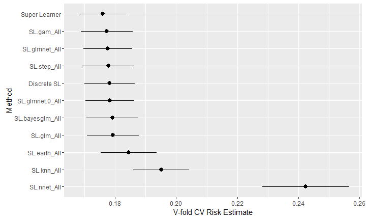

```r
plot(pm1, packag ="ggplot2")
```

## Best algorithm for each V-fold

```r
pm1$whichDiscreteSL
```

```
## $`1`
## [1] "SL.gam_All"
##
## $`2`
## [1] "SL.glmnet_All"
##
## $`3`
## [1] "SL.glmnet_All"
##
## $`4`
## [1] "SL.step_All"
##
## $`5`
## [1] "SL.glmnet_All"
##
## $`6`
## [1] "SL.step_All"
##
## $`7`
## [1] "SL.glmnet_All"
##
## $`8`
## [1] "SL.glmnet_All"
##
## $`9`
## [1] "SL.glmnet_All"
##
## $`10`
## [1] "SL.gam_All"
```

## Average of SuperLearner \(\alpha\) weights

```r
as.data.frame(colMeans(pm1$coef))
```

```
##                 colMeans(pm1$coef)
## SL.glm_All             0.000000000
## SL.bayesglm_All        0.000000000
## SL.earth_All           0.182184626
## SL.gam_All             0.238533673
## SL.glmnet_All          0.124057556
## SL.glmnet.0_All        0.000000000
## SL.knn_All             0.187070857
## SL.step_All            0.261432008
## SL.nnet_All            0.006721281
```

## Plot of AUROC curves for each algorithm

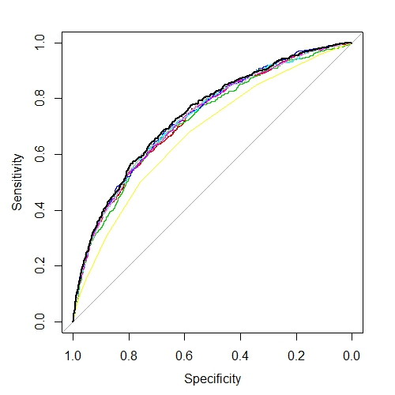

## Table of AUROC curves for each algorithm

```
##                              freqta
## SL.glm_All      0.731 (0.709-0.752)
## SL.bayesglm_All 0.731 (0.709-0.752)
## SL.earth_All      0.722 (0.7-0.744)
## SL.gam_All      0.738 (0.717-0.759)
## SL.glmnet_All   0.736 (0.714-0.757)
## SL.glmnet.0_All 0.733 (0.711-0.754)
## SL.knn_All      0.677 (0.654-0.699)
## SL.step_All     0.735 (0.714-0.757)
## SL.nnet_All     0.572 (0.547-0.596)
## SL.predict      0.743 (0.722-0.764)
```

## Run SuperLearner prediction model with variable screening algorithms

- Suppose you wish to limit the number of variables entered into the prediction model
- Specifically, you think that the 12 medical history variables aren’t helpful
- Can generate a screening algorithm to exclude those variables:

```r
screen.nohx <- function(...){
  return(c(rep(FALSE,12), rep(TRUE,33)))
  }
```

## Specify the SL library with prediction and variable screening algorithms

Note that I’m only including one prediction model (generalize additive model) for demonstration purposes

```r
SL.library2 <- list(c("SL.gam","All","screen.nohx","screen.glmnet"))

system.time({
pm2 <- CV.SuperLearner(Y=arf$death,
                       X=arf[1:45],
                       V=10, family=binomial(),
                       SL.library=SL.library2,
                       method="method.NNLS",
                       verbose = TRUE,
                       control = list(saveFitLibrary = TRUE),
                       cvControl = list(V=10), saveAll = TRUE,
                       parallel = 'multicore')

})[[3]]
```

## Results

```r
summary(pm2)
```

```
Risk is based on: Mean Squared Error

All risk estimates are based on V =  10

            Algorithm     Ave        se     Min     Max
        Super Learner 0.17643 0.0042621 0.15968 0.19481
          Discrete SL 0.17730 0.0043219 0.15640 0.19587
           SL.gam_All 0.17710 0.0043222 0.16020 0.19479
   SL.gam_screen.nohx 0.17762 0.0042853 0.16224 0.19560
 SL.gam_screen.glmnet 0.17666 0.0042918 0.15640 0.19587
```

```r
# Examine vars in best algorithm
out = c()
for(j in 1:10){
  out = c(out,names(pm2[["AllSL"]][[j]][["fitLibrary"]][[3]][[1]][["coefficients"]]))
  }
table(out); rm(out,j)
```

```
out
   (Intercept)          amihx          chfhx           dnr1         Female
            10              1              3             10             10
         gastr       gibledhx           hema        liverhx        malighx
             7              4             10             10             10
          meta          neuro        psychhx        renalhx           resp
             3              7              7              1              3
           rhc      s(age, 2)     s(alb1, 2)     s(aps1, 2)    s(bili1, 2)
            10             10             10             10             10
   s(crea1, 2) s(das2d3pc, 2)      s(edu, 2)    s(hema1, 2)     s(hrt1, 2)
             7             10              4              2              4
 s(meanbp1, 2)   s(paco21, 2)    s(pafi1, 2)    s(resp1, 2)   s(scoma1, 2)
             7              5             10              1             10
    s(sod1, 2)    s(temp1, 2)    s(wblc1, 2)           seps        transhx
             4              5              2              6              4
        trauma          white
             3              1
```

## Some (hopefully) helpful comments

## Basic observations

- Super Learner is not a magic bullet: crappy data = crappy predictions
- The screening algorithms seem to work better with many V folds and lots of data, the “chunk wise” variable selection method works best with smaller data sets
- Theory says you should use many prediction algorithms, but this can be computationally demanding

## Computation issues

Example computation times on different computers/R configurations

- Windows 10 laptop, 8 GB RAM, 4 logical cores/ R 3.02: 67 minutes
- UNIX desktop, 16 GB of RAM, 4 cores/ Microsoft Open R 3.02: 44 minutes
- UNIX desktop, 16 GB of RAM, 8 logical cores/ R 3.02: 31 minutes
- UNIX workstation, 64 GB of RAM, 16 logical cores/ R 3.02: 30 minutes

## Super Learner R package software

- Written in R in 2010
- Candidate algorithms are trained independently
- Can parallelize the cross-validation step via multicore or SNOW
- The meta-learning step has a small computational burden
- Possible to run out of memory while working with large training sets

## Two other options available

**subsemble R package**:

- Partitions the full dataset into subsets of observations
- Fits a specified underlying algorithm on each subset
- Uses a unique form of V-fold cross-validation to combine the subset-specific fits
- Using the UNIX workstation, computation time for the example went from 30 min to 1.6 min
- Still in development, does not provide CV risk estimates

**h2oEnsemble R package**: makes use of the h2o package, the R interface to the H2O platform, all training and data processing are performed in the high-performance H2O cluster

## Thank you!

## References

- van der Laan, M.J. and Rubin, D. (2006), Targeted Maximum Likelihood Learning. *The International Journal of Biostatistics*, 2(1). http://www.bepress.com/ijb/vol2/iss1/11/
- van der Laan, Mark J.; Polley, Eric C.; and Hubbard, Alan E., "Super Learner" (July 2007). *U.C. Berkeley Division of Biostatistics Working Paper Series*. Working Paper 222. http://biostats.bepress.com/ucbbiostat/paper222
- van der Laan, M.J. and Rose, S. *Targeted Learning: Causal Inference for Observational and Experimental Data*. Springer, Berlin Heidelberg New York, 2011. http://www.targetedlearningbook.com/

- Sapp, S.; van der Laan, M.J. and Canny, J. *Journal of Applied Statistics* (2013). Subsemble: An ensemble method for combining subset-specific algorithm fits. http://www.tandfonline.com/doi/abs/10.1080/02664763.2013.864263

## Software and online resources

- *SuperLearner: Super Learner Prediction* https://cran.r-project.org/web/packages/SuperLearner/index.html
- *tmle: Targeted Maximum Likelihood Estimation* https://cran.r-project.org/web/packages/tmle/index.html

- *subsemble: An Ensemble Method for Combining Subset-Specific Algorithm Fits* https://cran.r-project.org/web/packages/subsemble/index.html

- M. Petersen and L. Balzer. *Introduction to Causal Inference*. UC Berkeley, August 2014. http://www.ucbbiostat.com/
- This presentation, the data (with documentation) and R code is available at: https://github.com/sfgrey/Super-Learner-Presentation.git